# Insights into the 2022 FIFA World Cup

Rachel Anthony and Christian Sipley

2023-04-19

## Importing the Data

The FIFA data set was pulled from Kaggle at https://www.kaggle.com/datasets/die9origephit/fifa-world-cup-2022-complete-dataset. It provides 88 variables to analyze from the 2022 World Cup for each of the 64 games.

```r
dfFIFA <- read.csv("data/Fifa_world_cup_matches.csv")
```

## Data Cleaning and Preparation

To begin to understand the data we will be working with, we used the `str()` command on dfFIFA. This allows us to note what data structure each variable is in and whether that is the best structure for us to be working with in our analysis.

```r
str(dfFIFA)
```

```
## 'data.frame':    64 obs. of  88 variables:
##  $ team1                                                : chr  "QATAR" "ENGLAND" "SENEGAL" "UNITED STATES" ...
##  $ team2                                                : chr  "ECUADOR" "IRAN" "NETHERLANDS" "WALES" ...
##  $ possession.team1                                     : num  0.42 0.72 0.44 0.51 0.64 0.55 0.54 0.56 0.32 0.65 ...
##  $ possession.team2                                     : num  0.5 0.19 0.45 0.39 0.24 0.33 0.31 0.35 0.57 0.22 ...
##  $ possession.in.contest                                : num  0.08 0.09 0.11 0.1 0.12 0.12 0.15 0.09 0.12 0.13 ...
##  $ number.of.goals.team1                                : int  0 6 0 1 1 0 0 4 0 1 ...
##  $ number.of.goals.team2                                : int  2 2 2 1 2 0 0 1 0 2 ...
##  $ date                                                 : chr  "20-Nov-22" "21-Nov-22" "21-Nov-22" "21-Nov-22" ...
##  $ hour                                                 : chr  "17:00" "14:00" "17:00" "20:00" ...
##  $ category                                             : chr  "Group A" "Group B" "Group A" "Group B" ...
##  $ total.attempts.team1                                 : int  5 13 14 6 14 11 13 22 8 25 ...
##  $ total.attempts.team2                                 : int  6 8 9 7 3 11 8 4 6 10 ...
##  $ conceded.team1                                       : int  2 2 2 1 2 0 0 1 0 2 ...
##  $ conceded.team2                                       : int  0 6 0 1 1 0 0 4 0 1 ...
```

[output cut: 74 more lines]

The `date`, `category`, and `hour` variables need to be changed into different data types to be able to use them in analysis.

```r
# Convert category, hour, team1, team2 to a factor since it is a group variable
dfFIFA$category <- as.factor(dfFIFA$category)
dfFIFA$category <- as.factor(dfFIFA$category)
dfFIFA$hour <- as.factor(dfFIFA$hour)
dfFIFA$team1 <- as.factor(dfFIFA$team1)
dfFIFA$team2 <- as.factor(dfFIFA$team2)

# Convert date to a date
dfFIFA$date <- as.Date(dfFIFA$date, format = "%d-%b-%y")
```

Confirm the changes above have been made.

```r
str(dfFIFA$category)
```

```
##  Factor w/ 13 levels "Final","Group A",..: 2 3 2 3 4 5 4 5 7 6 ...
```

```r
str(dfFIFA$hour)
```

```
##  Factor w/ 5 levels "11:00","14:00",..: 4 2 4 5 1 2 4 5 1 2 ...
```

```r
str(dfFIFA$date)
```

```
##  Date[1:64], format: "2022-11-20" "2022-11-21" "2022-11-21" "2022-11-21" "2022-11-22" ...
```

## Normalizing the data

Put all the data for team 1 in one dataframe and all data for team 2 in another 1. team 1 and stats 2. team 2 and stats 3. game that has a game PK with links to the two team and all the game stats.

A game identifier column will be called `matchID` and is added to the existing `dfFIFA` using the `cbind()` function. `matchID` is created using the `seq()` function that will use increments of 1 to create the data.

```r
dfFIFA <- data.frame(cbind(matchID = c(seq(1:64)), dfFIFA))
```

Create two columns `result` and `team2won` using a vector of TRUE and FALSE to put either a 1 or 0 based on if they won or not. A 1 means they won. This will be the outcome variable that will be used when creating the models. Ties mean that both are 0, and we are only looking at definite wins in our model.

```r
# create column if team 1 won
result <- dfFIFA$number.of.goals.team1 > dfFIFA$number.of.goals.team2
dfFIFA$result[result] <- 1
dfFIFA$result[!result] <- 0

# create column if team 2 won
team2won <- dfFIFA$number.of.goals.team1 < dfFIFA$number.of.goals.team2
dfFIFA$team2won[team2won] <- 1
dfFIFA$team2won[!team2won] <- 0
```

```r
dfFIFA$result <- as.factor(dfFIFA$result)
dfFIFA$team2won <-as.factor(dfFIFA$team2won)
```

Create a new data frame that pulls only information about the game, and use a sequence to create a key that identifies the match. The columns to put in this data frame are `team1` `team2` `date` `hour` and `category`.

```r
dfGameFIFA <- data.frame(dfFIFA$matchID, dfFIFA$team1, dfFIFA$team2, dfFIFA$category, dfFIFA$hour, dfFIFA$date, dfFIFA$possession.in.contest)
```

To create the team data frame, odd and even indexes will be used to select only some columns so that there are not duplicates. `rbind()` will be used to select the information for the other teams.

```r
# for team 1 columns
even_indexes<-seq(12,90,2)

# for team 2 columns
odd_indexes<-seq(13,91,2)
```

```r
# create the data frame that has the data just for team 1
dfTeam1 <- data.frame(dfFIFA$matchID, dfFIFA$team1, dfFIFA$possession.team1, dfFIFA$number.of.goals.team1, dfFIFA[,even_indexes])
```

```r
# create the data frame that has the data just for team 2
dfTeam2 <- data.frame(dfFIFA$matchID, dfFIFA$team2, dfFIFA$possession.team2, dfFIFA$number.of.goals.team2, dfFIFA[,odd_indexes])
```

```r
# the column names of the two data frames must be the same for rbind() to be successful
names(dfTeam2) <- names(dfTeam1)

# merge the two team data frames into 1
dfTeams <- data.frame(rbind(dfTeam1, dfTeam2))
```

```r
names(dfTeams) <- sub("\\.team1", "", names(dfTeams))

colnames(dfTeams)[1] ="matchID"
colnames(dfTeams)[2] ="team.name"
colnames(dfTeams)[3] ="possession"
colnames(dfTeams)[4] ="number.of.goals"
colnames(dfTeams)[13] ="attempts.outside.the.penalty.area"
colnames(dfTeams)[25] ="completed.line.breaks"
colnames(dfTeams)[27] ="completed.defensive.line.breaks"
colnames(dfTeams)[44] ="result"
```

## QUESTION OF INTEREST:

## WHAT DOES IT TAKE TO WIN A GAME IN THE 2022 FIFA WORLD CUP?

Our question explores the variables that are most important in determining who wins a game in the World Cup. To determine this, we will begin exploring our data through a variety of tabular and visual data.

## Exploratory Data Analysis

Data visualization that will help with variable selection.

Import these libraries that will be used in our EDA.

```r
library(ggplot2)

library(corrplot)
library(dplyr)
library(caret)
library(rpart)

library(rpart.plot)
```

We now wanted to visually explore the data to ensure that we are selecting the correct variables and this will help us actually see anything we could have missed. Once we loaded our libraries, we first decided to explore the Team data through a scatter matrix. The right most side would be the final result whether it is a win or not. The first matrix displays columns 3 through 10. An example of a strong relationship that is positively correlated is the variables `goals scored` and `number of attempts inside the penalty area`. This makes sense due to the fact that the penalty area is the closest area by the goal. The closer you are taking shots at the goal, the more likely you are to score. We also know that the ‘Goals’ and `Assists` are directly related to the result of any sport game. Two other variables that had a positive trend are `possession` and `total attempts`. We can conclude that when a team has possessed the ball more than their opponent, they are more likely to get more attempts on net. Thus, we can then look at how `possession` and `total attempts` and see how they correlate to `Goals` which then determine the outcome of the game. Overall, this first scatter matrix allowed us to establish heavily weighted variables that the number of goals and assists are dependent on to determine the final result.

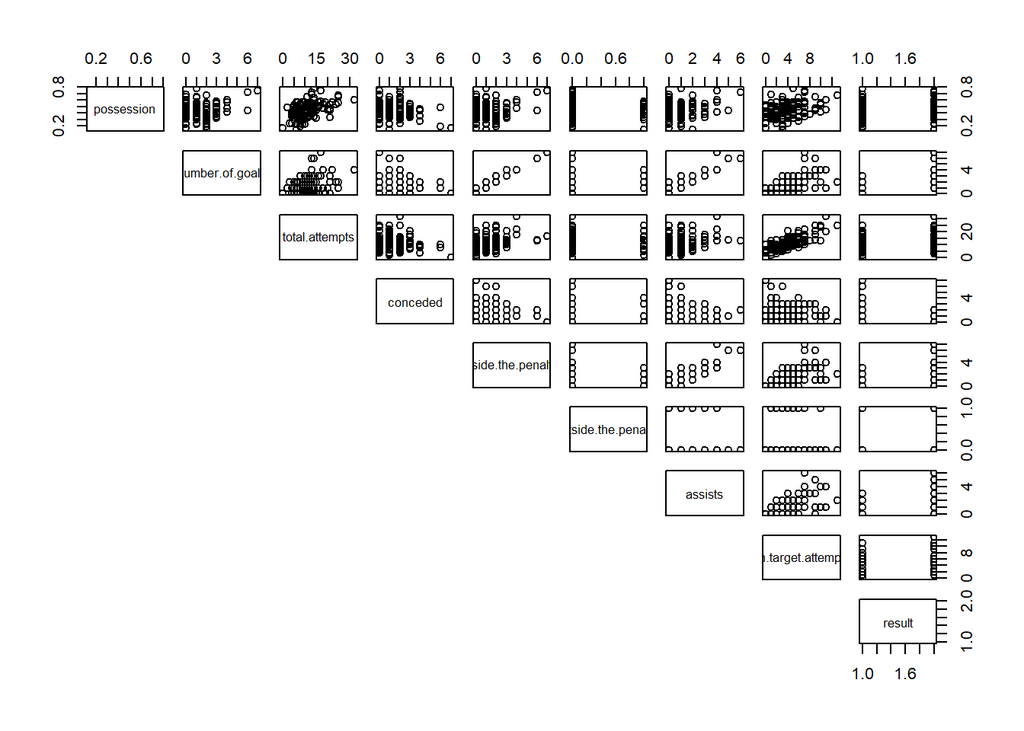

```r
scatter_matrix1 <- pairs(dfTeams[,c(3:10, 44)], lower.panel = NULL)
```

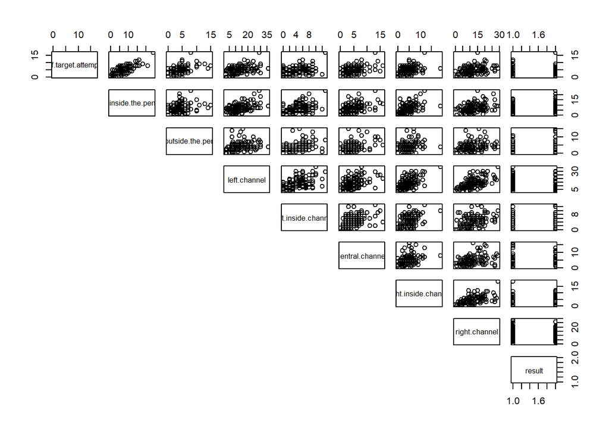

```r
scatter_matrix2 <- pairs(dfTeams[,c(11:18, 44)], lower.panel = NULL)
```

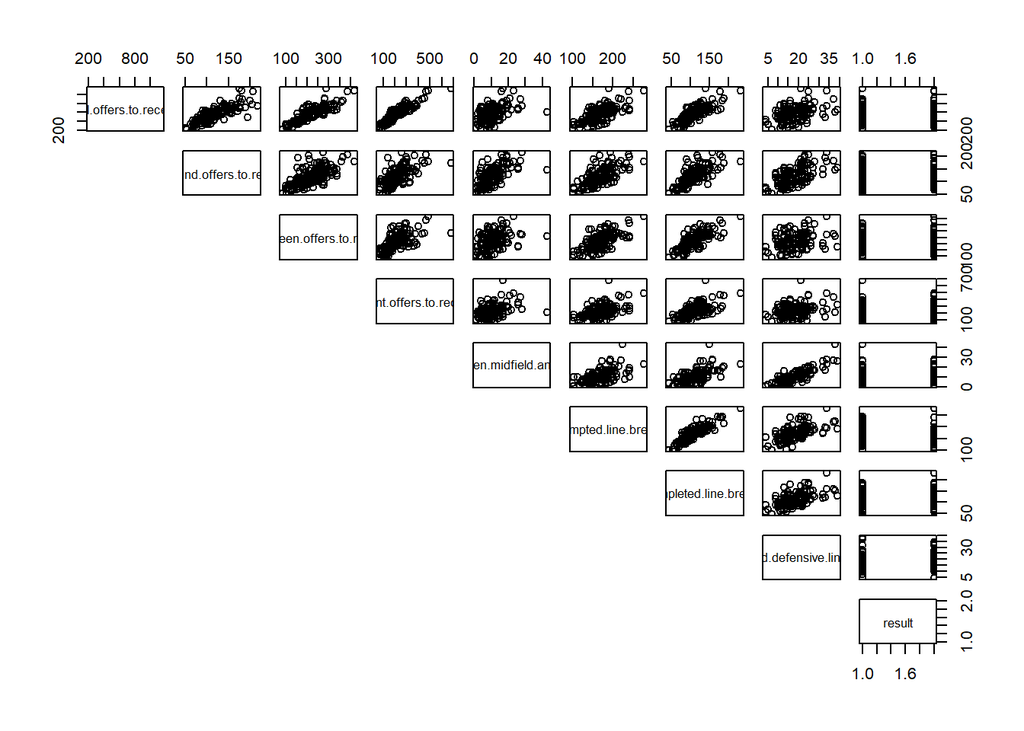

```r
scatter_matrix3 <- pairs(dfTeams[,c(19:26, 44)], lower.panel = NULL)
```

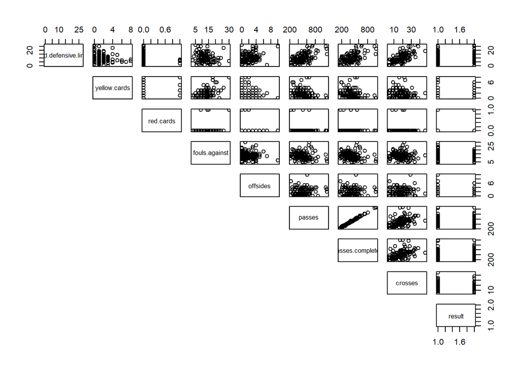

```r
scatter_matrix4 <- pairs(dfTeams[,c(27:34, 44)], lower.panel = NULL)
```

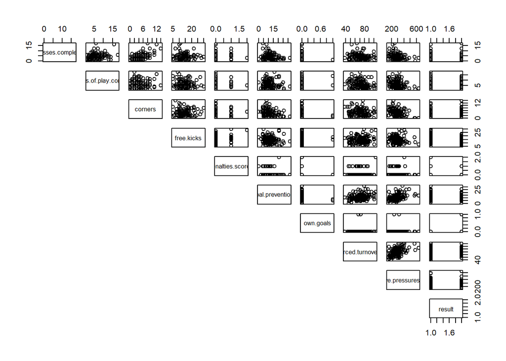

```r
scatter_matrix5 <- pairs(dfTeams[,c(35:44)], lower.panel = NULL)
```

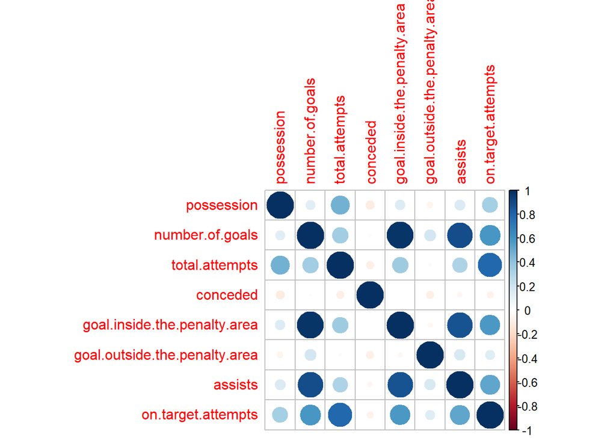

```r
# CORRPLOT 1
correl1 = cor(dfTeams[,c(3:10)])

corrplot(correl1)
```

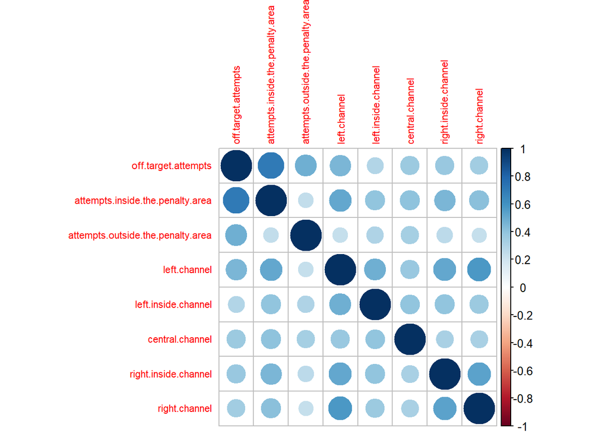

```r
# CORRPLOT 2
correl2 = cor(dfTeams[,c(11:18)])

corrplot(correl2, tl.cex = 0.7)
```

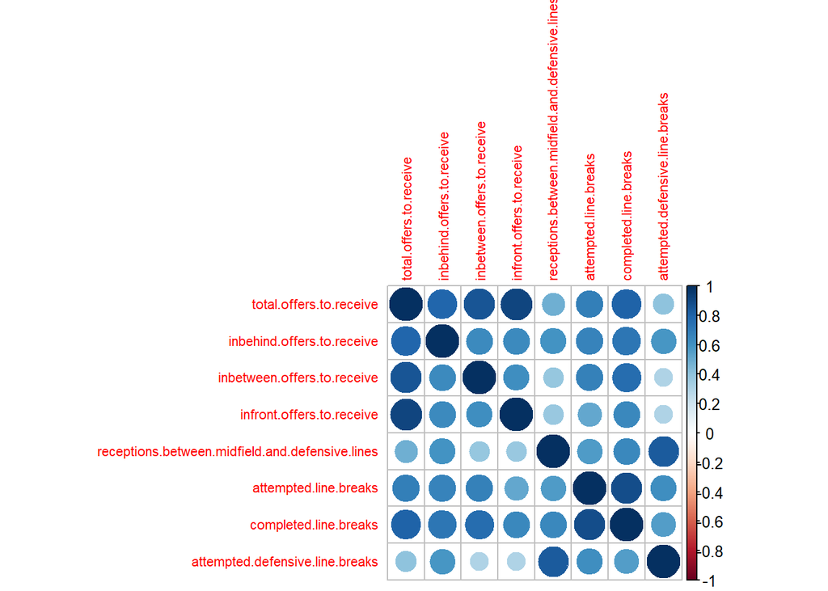

```r
# CORRPLOT 3
correl3 = cor(dfTeams[,c(19:26)])

corrplot(correl3, tl.cex = 0.7)
```

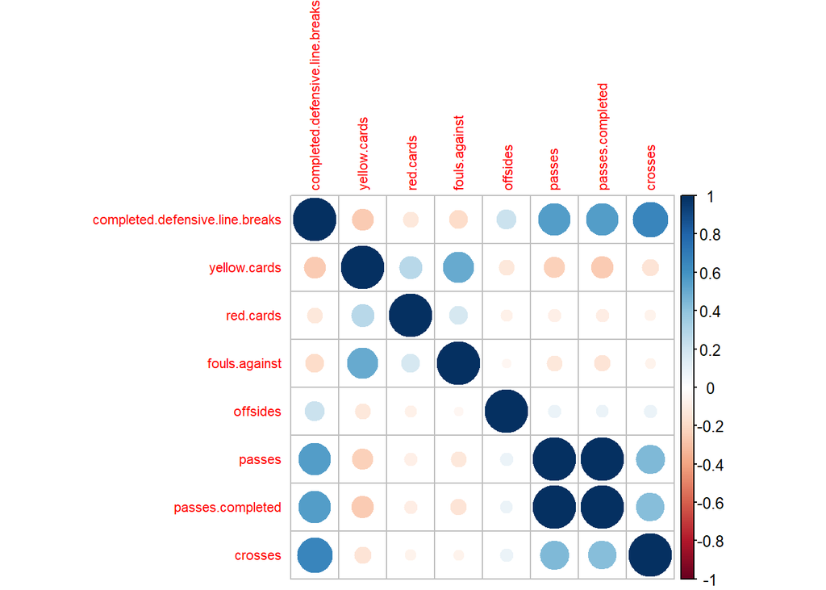

```r
# CORRPLOT 4
correl4 = cor(dfTeams[,c(27:34)])

corrplot(correl4, tl.cex = 0.7)
```

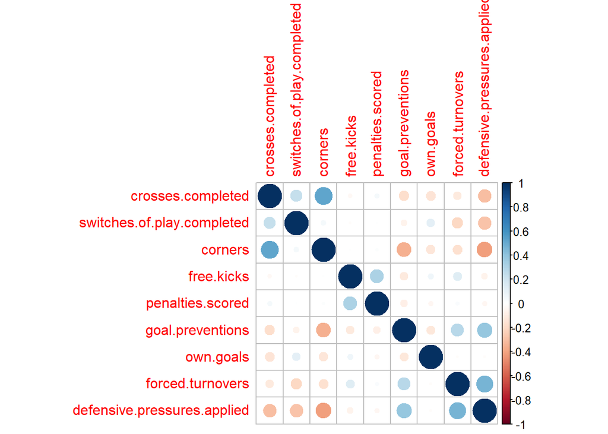

```r
# CORRPLOT 5
correl5 = cor(dfTeams[,c(35:43)])

corrplot(correl5)
```

For the next visualization, we wanted to use correlation plots as these are another great way to visualize the strength of relationships between variables. Taking a look at the first plot, we began to see very similar results as the scatters. We saw that as a team increases the amount of ‘possession’ the team should have a higher probability of getting more attempts on goal. However, this does not necessarily mean that more possession means the team is going to win. Another important relationship to highlight is ‘completed defensive line breaks’ and the total number of ‘passes completed’. We can conclude that a team that passes the ball more will ultimately get more completed line breaks which will result in more attempts on target.

```r
histo <- ggplot(dfTeams, aes(x = attempts.inside.the.penalty.area, fill = result)) +
  geom_histogram(bins = 15) +
  ggtitle("Histogram of the Number of Attempts Inside the Penalty Area by Winner of Match") +
  xlab("Number of Attempts Inside the Penalty Area") +
  scale_fill_manual(name = "Outcome", values=c("red", "green"), labels=c("Lost", "Won"))
```

```r
  library(GGally)
```

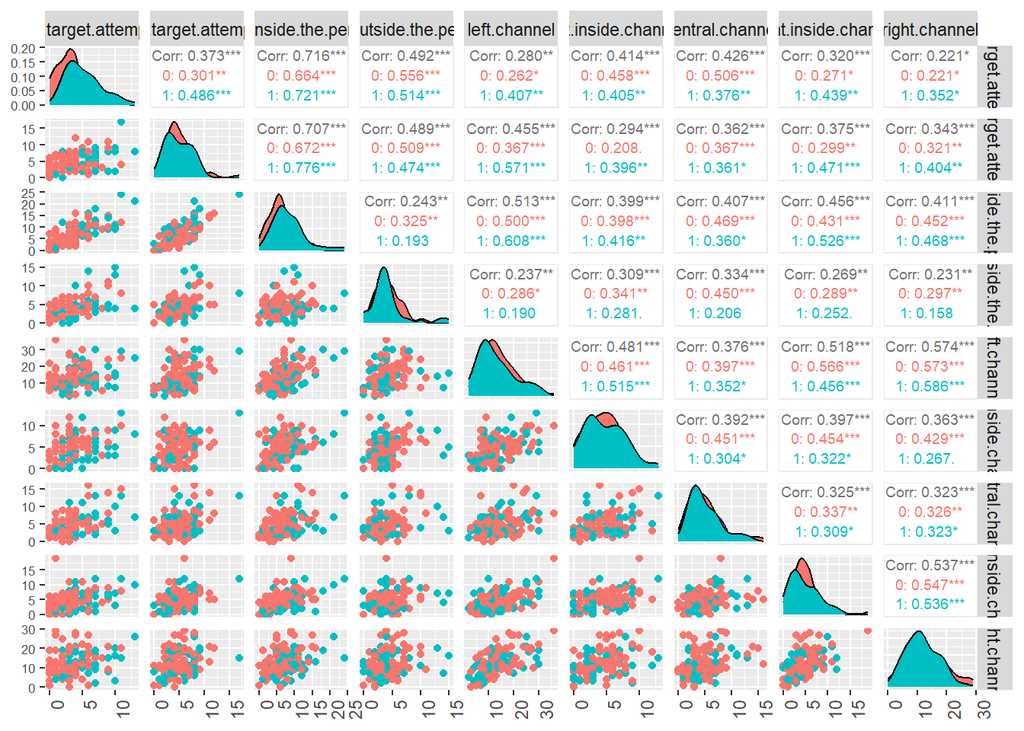

```r
  ggpairs(dfTeams, columns = 10:18, aes(color = result), upper = list(continuous = wrap("cor", size = 2.5))) +
    theme(axis.text.x = element_text(angle = 90, hjust = 1), axis.text.y = element_text(hjust = 1, size = 6.5))
```

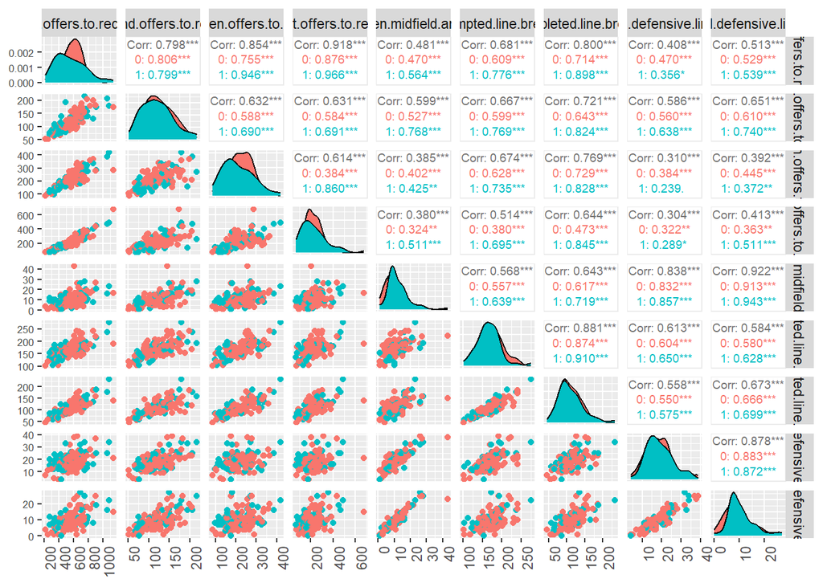

```r
  ggpairs(dfTeams, columns = 19:27, aes(color = result), upper = list(continuous = wrap("cor", size = 2.5))) +
    theme(axis.text.x = element_text(angle = 90, hjust = 1), axis.text.y = element_text(hjust = 1, size = 6.5))
```

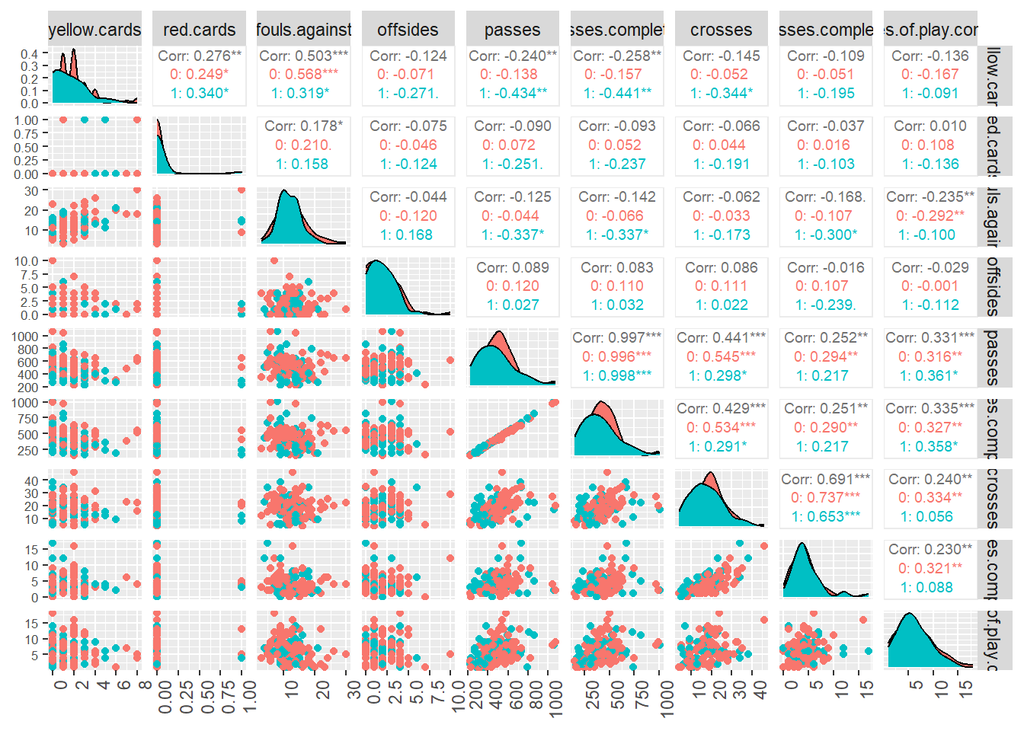

```r
  ggpairs(dfTeams, columns = 28:36, aes(color = result), upper = list(continuous = wrap("cor", size = 2.5))) +
    theme(axis.text.x = element_text(angle = 90, hjust = 1), axis.text.y = element_text(hjust = 1, size = 6.5))
```

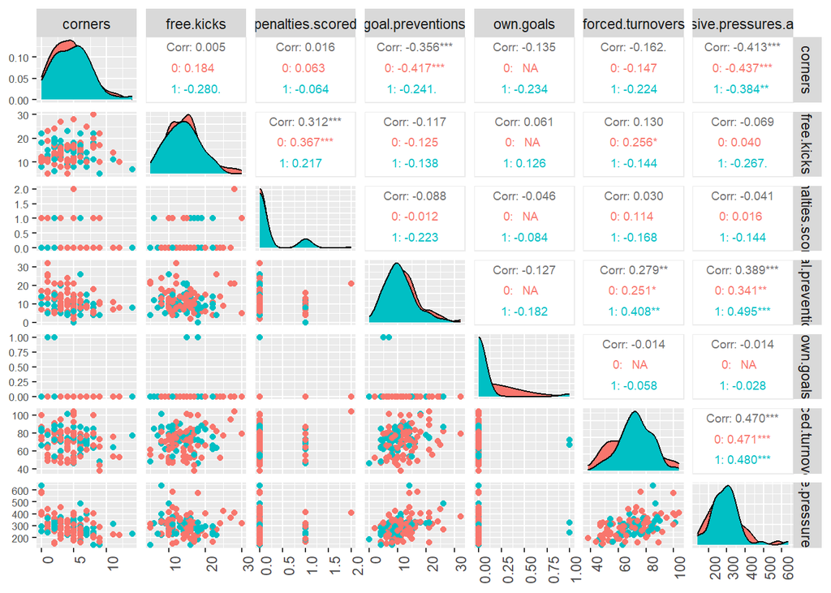

```r
  ggpairs(dfTeams, columns = 37:43, aes(color = result), upper = list(continuous = wrap("cor", size = 2.5))) +
    theme(axis.text.x = element_text(angle = 90, hjust = 1), axis.text.y = element_text(hjust = 1, size = 6.5))
```

## Building Models

Before building the models, the `dfTeams` data set must be split into a training and testing set. The `createDataParition()` function from the `caret` package will be used to do so. The split will be 80/20.

```r
set.seed(123)
inTrain <- createDataPartition(
  y = dfTeams$result,
  p = .80,
  list = FALSE
)

team_train <- dfTeams[inTrain,]
team_test <- dfTeams[-inTrain,]
```

### Null Model

The null model is the simplest model and predicts a 0 for every entry. We started with this model because it is best to start with the simplest model first and then try more complex ones. The accuracy of this model can be found below for both the training and the testing set. A confusion matrix is used to determine the number of true positives, true negatives, false positives, and false negatives.

```r
# Create a vector of 0's
model_train_null <- rep(0, nrow(team_train))
model_test_null <- rep(0, nrow(team_test))

cm_train_null <- caret::confusionMatrix(as.factor(model_train_null), team_train$result, positive="1")
cm_train_null
```

```
## Confusion Matrix and Statistics
##
##           Reference
## Prediction  0  1
##          0 64 40
##          1  0  0
##
##                Accuracy : 0.6154
##                  95% CI : (0.5149, 0.7091)
##     No Information Rate : 0.6154
##     P-Value [Acc > NIR] : 0.5432
##
##                   Kappa : 0
##
##  Mcnemar's Test P-Value : 6.984e-10
##
##             Sensitivity : 0.0000
##             Specificity : 1.0000
##          Pos Pred Value :    NaN
##          Neg Pred Value : 0.6154
##              Prevalence : 0.3846
##          Detection Rate : 0.0000
##    Detection Prevalence : 0.0000
##       Balanced Accuracy : 0.5000
##
##        'Positive' Class : 1
##
```

```r
cm_test_null <- caret::confusionMatrix(as.factor(model_test_null), team_test$result, positive="1")
cm_test_null
```

```
## Confusion Matrix and Statistics
##
##           Reference
## Prediction  0  1
##          0 15  9
##          1  0  0
##
##                Accuracy : 0.625
##                  95% CI : (0.4059, 0.812)
##     No Information Rate : 0.625
##     P-Value [Acc > NIR] : 0.589845
##
##                   Kappa : 0
##
##  Mcnemar's Test P-Value : 0.007661
##
##             Sensitivity : 0.000
##             Specificity : 1.000
##          Pos Pred Value :   NaN
##          Neg Pred Value : 0.625
##              Prevalence : 0.375
##          Detection Rate : 0.000
##    Detection Prevalence : 0.000
##       Balanced Accuracy : 0.500
##
##        'Positive' Class : 1
##
```

From the confusion matrix, we can see that the null model did not accurately predict any true positives, which is why the sensitivity is 0.000, but it did accurately predict some true negatives, which is also why the specificity is 1.000. Looking solely at the accuracy at 0.625, the model does not perform terribly, but when taking into account the sensitivity and specificity, it is clear that the null model is not a good predictor of our outcome variable.

### Logistic Regression

Next, we tried using a logistic regression model to predict our outcome variable. A logistic regression was used rather than a linear regression because our outcome variable is binary (categorical) rather than continuous, and so the linear model could not be applied. The `glm()` function is used to create the model and the variables passed into the model were selected based on our EDA. Three different logistic regression models were used with different variables to try to build the model that best predicts the `result` outcome variable. For each model that was constructed, a corresponding confusion matrix was created to explain the performance of the models to be used to determine which of the three logistic regression models was the best.

#### Logistic Regression Models on the Training Set

```r
# Fit model
model_lr1 <- glm(result ~ total.offers.to.receive + passes + assists + receptions.between.midfield.and.defensive.lines,
               data=team_train, family=binomial(link="logit"))

## Convert fitted model values to fitted classes
fitted_class_lr1 <- (model_lr1$fit > 0.5) * 1

# Create and display confusion matrix

cm_train_lr1 <- confusionMatrix(as.factor(fitted_class_lr1), as.factor(model_lr1$y), positive="1")

cm_train_lr1
```

```
## Confusion Matrix and Statistics
##
##           Reference
## Prediction  0  1
##          0 57 12
##          1  7 28
##
##                Accuracy : 0.8173
##                  95% CI : (0.7295, 0.8863)
##     No Information Rate : 0.6154
##     P-Value [Acc > NIR] : 7.127e-06
##
##                   Kappa : 0.6048
##
##  Mcnemar's Test P-Value : 0.3588
##
##             Sensitivity : 0.7000
##             Specificity : 0.8906
##          Pos Pred Value : 0.8000
##          Neg Pred Value : 0.8261
##              Prevalence : 0.3846
##          Detection Rate : 0.2692
##    Detection Prevalence : 0.3365
##       Balanced Accuracy : 0.7953
##
##        'Positive' Class : 1
##
```

```r
# Fit model
model_lr2 <- glm(result ~ passes.completed + crosses + corners + switches.of.play.completed,
               data=team_train, family=binomial(link="logit"))

## Convert fitted model values to fitted classes
fitted_class_lr2 <- (model_lr2$fit > 0.5) * 1

# Create and display confusion matrix

cm_train_lr2 <- confusionMatrix(as.factor(fitted_class_lr2), as.factor(model_lr2$y), positive="1")

cm_train_lr2
```

```
## Confusion Matrix and Statistics
##
##           Reference
## Prediction  0  1
##          0 53 32
##          1 11  8
##
##                Accuracy : 0.5865
##                  95% CI : (0.4858, 0.6823)
##     No Information Rate : 0.6154
##     P-Value [Acc > NIR] : 0.760867
##
##                   Kappa : 0.0312
##
##  Mcnemar's Test P-Value : 0.002289
##
##             Sensitivity : 0.20000
##             Specificity : 0.82812
##          Pos Pred Value : 0.42105
##          Neg Pred Value : 0.62353
##              Prevalence : 0.38462
##          Detection Rate : 0.07692
##    Detection Prevalence : 0.18269
##       Balanced Accuracy : 0.51406
##
##        'Positive' Class : 1
##
```

```r
# Fit model
model_lr3 <- glm(result ~ passes + on.target.attempts + possession + receptions.between.midfield.and.defensive.lines + crosses,
               data=team_train, family=binomial(link="logit"))

## Convert fitted model values to fitted classes
fitted_class_lr3 <- (model_lr3$fit > 0.5) * 1

# Create and display confusion matrix

cm_train_lr3 <- confusionMatrix(as.factor(fitted_class_lr3), as.factor(model_lr3$y), positive="1")

cm_train_lr3
```

```
## Confusion Matrix and Statistics
##
##           Reference
## Prediction  0  1
##          0 54 16
##          1 10 24
##
##                Accuracy : 0.75
##                  95% CI : (0.6555, 0.8297)
##     No Information Rate : 0.6154
##     P-Value [Acc > NIR] : 0.002632
##
##                   Kappa : 0.4566
##
##  Mcnemar's Test P-Value : 0.326800
##
##             Sensitivity : 0.6000
##             Specificity : 0.8438
##          Pos Pred Value : 0.7059
##          Neg Pred Value : 0.7714
##              Prevalence : 0.3846
##          Detection Rate : 0.2308
##    Detection Prevalence : 0.3269
##       Balanced Accuracy : 0.7219
##
##        'Positive' Class : 1
##
```

We used the `sprintf()` method to pull specific values from the confusion matrix for each logistic regression model and output them all in a single spot. The measures of the confusion matrix could be pulled using the syntax below since its data structure is a list.

```r
# Logistic Regression Model #1
sprintf("Logistic Model #1 - Training Set:  Accuracy = %8.4f  Sensitivity = %8.4f  Specificity = %8.4f  F1 = %8.4f",
        cm_train_lr1$overall["Accuracy"],
        cm_train_lr1$byClass["Sensitivity"],
        cm_train_lr1$byClass["Specificity"],
        cm_train_lr1$byClass["F1"])
```

```
## [1] "Logistic Model #1 - Training Set:  Accuracy =   0.8173  Sensitivity =   0.7000  Specificity =   0.8906  F1 =   0.7467"
```

```r
# Logistic Regression Model #2
sprintf("Logistic Model #2 - Training Set:  Accuracy = %8.4f  Sensitivity = %8.4f  Specificity = %8.4f  F1 = %8.4f",
        cm_train_lr2$overall["Accuracy"],
        cm_train_lr2$byClass["Sensitivity"],
        cm_train_lr2$byClass["Specificity"],
        cm_train_lr2$byClass["F1"])
```

```
## [1] "Logistic Model #2 - Training Set:  Accuracy =   0.5865  Sensitivity =   0.2000  Specificity =   0.8281  F1 =   0.2712"
```

```r
# Logistic Regression Model #3
sprintf("Logistic Model #3 - Training Set:  Accuracy = %8.4f  Sensitivity = %8.4f  Specificity = %8.4f  F1 = %8.4f",
        cm_train_lr3$overall["Accuracy"],
        cm_train_lr3$byClass["Sensitivity"],
        cm_train_lr3$byClass["Specificity"],
        cm_train_lr3$byClass["F1"])
```

```
## [1] "Logistic Model #3 - Training Set:  Accuracy =   0.7500  Sensitivity =   0.6000  Specificity =   0.8438  F1 =   0.6486"
```

As mentioned previously, we used a variety of variables in each model to try to select the ones that are best at predicting the outcome of a match based on the least amount of variables to build the most parsimonious model. Looking solely at how the models perform on the training sets, we concluded logistic regression model #3 was the best model, even though model #1 had more accurate performance. However, we determined that the `assists` variable was too correlated to our outcome one, which hindered its usability. Logistic model #3 had a high accuracy and specificity and a moderately high sensitivity with values at 0.75, 0.84, and 0.60, respectively.

#### Logistic Regression Models on the Testing Set

```r
# Make predictions on test data set
pred_lr1 <- predict(model_lr1, newdata = team_test, type = "response")


predicted_class_lr1 <- (pred_lr1 > 0.5) * 1

cm_test_lr1 <- confusionMatrix(as.factor(predicted_class_lr1), team_test$result, positive="1")

cm_test_lr1
```

```
## Confusion Matrix and Statistics
##
##           Reference
## Prediction  0  1
##          0 12  0
##          1  3  9
##
##                Accuracy : 0.875
##                  95% CI : (0.6764, 0.9734)
##     No Information Rate : 0.625
##     P-Value [Acc > NIR] : 0.006967
##
##                   Kappa : 0.75
##
##  Mcnemar's Test P-Value : 0.248213
##
##             Sensitivity : 1.000
##             Specificity : 0.800
##          Pos Pred Value : 0.750
##          Neg Pred Value : 1.000
##              Prevalence : 0.375
##          Detection Rate : 0.375
##    Detection Prevalence : 0.500
##       Balanced Accuracy : 0.900
##
##        'Positive' Class : 1
##
```

```r
# Make predictions on test data set
pred_lr2 <- predict(model_lr2, newdata = team_test, type = "response")


predicted_class_lr2 <- (pred_lr2 > 0.5) * 1

cm_test_lr2 <- confusionMatrix(as.factor(predicted_class_lr2), team_test$result, positive="1")

cm_test_lr2
```

```
## Confusion Matrix and Statistics
##
##           Reference
## Prediction  0  1
##          0 15  8
##          1  0  1
##
##                Accuracy : 0.6667
##                  95% CI : (0.4468, 0.8437)
##     No Information Rate : 0.625
##     P-Value [Acc > NIR] : 0.42353
##
##                   Kappa : 0.1351
##
##  Mcnemar's Test P-Value : 0.01333
##
##             Sensitivity : 0.11111
##             Specificity : 1.00000
##          Pos Pred Value : 1.00000
##          Neg Pred Value : 0.65217
##              Prevalence : 0.37500
##          Detection Rate : 0.04167
##    Detection Prevalence : 0.04167
##       Balanced Accuracy : 0.55556
##
##        'Positive' Class : 1
##
```

```r
# Make predictions on test data set
pred_lr3 <- predict(model_lr3, newdata = team_test, type = "response")


predicted_class_lr3 <- (pred_lr3 > 0.5) * 1

cm_test_lr3 <- confusionMatrix(as.factor(predicted_class_lr3), team_test$result, positive="1")

cm_test_lr3
```

```
## Confusion Matrix and Statistics
##
##           Reference
## Prediction  0  1
##          0 11  3
##          1  4  6
##
##                Accuracy : 0.7083
##                  95% CI : (0.4891, 0.8738)
##     No Information Rate : 0.625
##     P-Value [Acc > NIR] : 0.2676
##
##                   Kappa : 0.3913
##
##  Mcnemar's Test P-Value : 1.0000
##
##             Sensitivity : 0.6667
##             Specificity : 0.7333
##          Pos Pred Value : 0.6000
##          Neg Pred Value : 0.7857
##              Prevalence : 0.3750
##          Detection Rate : 0.2500
##    Detection Prevalence : 0.4167
##       Balanced Accuracy : 0.7000
##
##        'Positive' Class : 1
##
```

```r
# Logistic Regression Model #1
sprintf("Logistic Model #1 - Test Set:  Accuracy = %8.4f  Sensitivity = %8.4f  Specificity = %8.4f  F1 = %8.4f",
        cm_test_lr1$overall["Accuracy"],
        cm_test_lr1$byClass["Sensitivity"],
        cm_test_lr1$byClass["Specificity"],
        cm_test_lr1$byClass["F1"])
```

```
## [1] "Logistic Model #1 - Test Set:  Accuracy =   0.8750  Sensitivity =   1.0000  Specificity =   0.8000  F1 =   0.8571"
```

```r
# Logistic Regression Model #2
sprintf("Logistic Model #2 - Test Set:  Accuracy = %8.4f  Sensitivity = %8.4f  Specificity = %8.4f  F1 = %8.4f",
        cm_test_lr2$overall["Accuracy"],
        cm_test_lr2$byClass["Sensitivity"],
        cm_test_lr2$byClass["Specificity"],
        cm_test_lr2$byClass["F1"])
```

```
## [1] "Logistic Model #2 - Test Set:  Accuracy =   0.6667  Sensitivity =   0.1111  Specificity =   1.0000  F1 =   0.2000"
```

```r
# Logistic Regression Model #3
sprintf("Logistic Model #3 - Test Set:  Accuracy = %8.4f  Sensitivity = %8.4f  Specificity = %8.4f  F1 = %8.4f",
        cm_test_lr3$overall["Accuracy"],
        cm_test_lr3$byClass["Sensitivity"],
        cm_test_lr3$byClass["Specificity"],
        cm_test_lr3$byClass["F1"])
```

```
## [1] "Logistic Model #3 - Test Set:  Accuracy =   0.7083  Sensitivity =   0.6667  Specificity =   0.7333  F1 =   0.6316"
```

### Classification and Regression Tree

It is important to try multiple different model types when trying performing data modeling, which is why we decided to build a classification and regression tree model(CART) using the same sets of variables we used in all three logistic regression models. CART models perform a series of splits on the data and predict the outcomes based on different values and splits. The function used to build CART models is the `rpart()` function and the method is `class`. As with the logistic regresison models, we need to renumber the values produced by the function to have them be either 0 or 1 to match our outcome variable categories.

#### CART Models on the Training Set

```r
model_tree1 <- rpart(result ~ total.offers.to.receive + passes + assists + receptions.between.midfield.and.defensive.lines,
               data=team_train, method = "class")

fitted_class_tree1 <- predict(model_tree1, type="class")

model_tree1$y <- model_tree1$y - 1

cm_train_tree1 <- confusionMatrix(as.factor(fitted_class_tree1), as.factor(model_tree1$y), positive="1")
cm_train_tree1
```

```
## Confusion Matrix and Statistics
##
##           Reference
## Prediction  0  1
##          0 58  8
##          1  6 32
##
##                Accuracy : 0.8654
##                  95% CI : (0.7845, 0.9244)
##     No Information Rate : 0.6154
##     P-Value [Acc > NIR] : 1.711e-08
##
##                   Kappa : 0.7129
##
##  Mcnemar's Test P-Value : 0.7893
##
##             Sensitivity : 0.8000
##             Specificity : 0.9062
##          Pos Pred Value : 0.8421
##          Neg Pred Value : 0.8788
##              Prevalence : 0.3846
##          Detection Rate : 0.3077
##    Detection Prevalence : 0.3654
##       Balanced Accuracy : 0.8531
##
##        'Positive' Class : 1
##
```

```r
model_tree2 <- rpart(result ~ passes.completed + crosses + corners + switches.of.play.completed,
               data=team_train, method = "class")

fitted_class_tree2 <- predict(model_tree2, type="class")

model_tree2$y <- model_tree2$y - 1

cm_train_tree2 <- confusionMatrix(as.factor(fitted_class_tree2), as.factor(model_tree2$y), positive="1")
cm_train_tree2
```

```
## Confusion Matrix and Statistics
##
##           Reference
## Prediction  0  1
##          0 46  9
##          1 18 31
##
##                Accuracy : 0.7404
##                  95% CI : (0.6452, 0.8214)
##     No Information Rate : 0.6154
##     P-Value [Acc > NIR] : 0.004998
##
##                   Kappa : 0.4738
##
##  Mcnemar's Test P-Value : 0.123658
##
##             Sensitivity : 0.7750
##             Specificity : 0.7188
##          Pos Pred Value : 0.6327
##          Neg Pred Value : 0.8364
##              Prevalence : 0.3846
##          Detection Rate : 0.2981
##    Detection Prevalence : 0.4712
##       Balanced Accuracy : 0.7469
##
##        'Positive' Class : 1
##
```

```r
model_tree3 <- rpart(result ~ passes + on.target.attempts + possession + receptions.between.midfield.and.defensive.lines +   crosses, data=team_train, method = "class")

fitted_class_tree3 <- predict(model_tree3, type="class")

model_tree3$y <- model_tree3$y - 1

cm_train_tree3 <- confusionMatrix(as.factor(fitted_class_tree3), as.factor(model_tree3$y), positive="1")
cm_train_tree3
```

```
## Confusion Matrix and Statistics
##
##           Reference
## Prediction  0  1
##          0 52 11
##          1 12 29
##
##                Accuracy : 0.7788
##                  95% CI : (0.6869, 0.8543)
##     No Information Rate : 0.6154
##     P-Value [Acc > NIR] : 0.0002876
##
##                   Kappa : 0.535
##
##  Mcnemar's Test P-Value : 1.0000000
##
##             Sensitivity : 0.7250
##             Specificity : 0.8125
##          Pos Pred Value : 0.7073
##          Neg Pred Value : 0.8254
##              Prevalence : 0.3846
##          Detection Rate : 0.2788
##    Detection Prevalence : 0.3942
##       Balanced Accuracy : 0.7688
##
##        'Positive' Class : 1
##
```

```r
# CART Model #1
sprintf("Decision Tree Model #1 - Training Set:  Accuracy = %8.4f  Sensitivity = %8.4f  Specificity = %8.4f  F1 = %8.4f",
        cm_train_tree1$overall["Accuracy"],
        cm_train_tree1$byClass["Sensitivity"],
        cm_train_tree1$byClass["Specificity"],
        cm_train_tree1$byClass["F1"])
```

```
## [1] "Decision Tree Model #1 - Training Set:  Accuracy =   0.8654  Sensitivity =   0.8000  Specificity =   0.9062  F1 =   0.8205"
```

```r
# CART Model #2
sprintf("Decision Tree Model #2 - Training Set:  Accuracy = %8.4f  Sensitivity = %8.4f  Specificity = %8.4f  F1 = %8.4f",
        cm_train_tree2$overall["Accuracy"],
        cm_train_tree2$byClass["Sensitivity"],
        cm_train_tree2$byClass["Specificity"],
        cm_train_tree2$byClass["F1"])
```

```
## [1] "Decision Tree Model #2 - Training Set:  Accuracy =   0.7404  Sensitivity =   0.7750  Specificity =   0.7188  F1 =   0.6966"
```

```r
# CART Model #3
sprintf("Decision Tree Model #3 - Training Set:  Accuracy = %8.4f  Sensitivity = %8.4f  Specificity = %8.4f  F1 = %8.4f",
        cm_train_tree3$overall["Accuracy"],
        cm_train_tree3$byClass["Sensitivity"],
        cm_train_tree3$byClass["Specificity"],
        cm_train_tree3$byClass["F1"])
```

```
## [1] "Decision Tree Model #3 - Training Set:  Accuracy =   0.7788  Sensitivity =   0.7250  Specificity =   0.8125  F1 =   0.7160"
```

#### CART Models Graphically

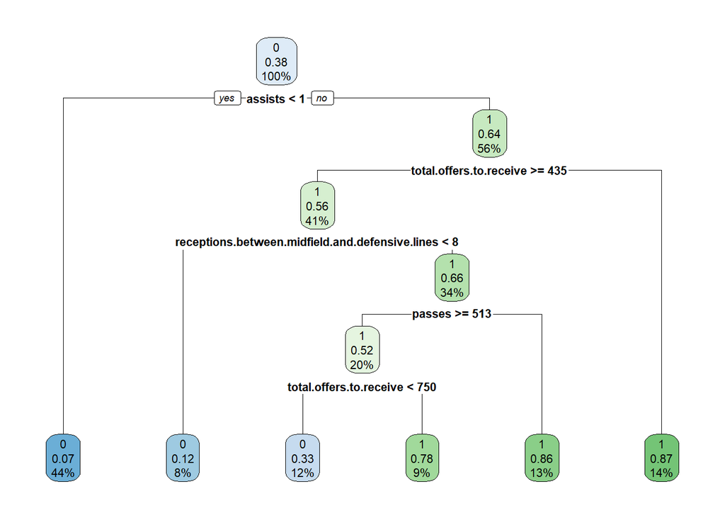

```r
rpart.plot(model_tree1)
```

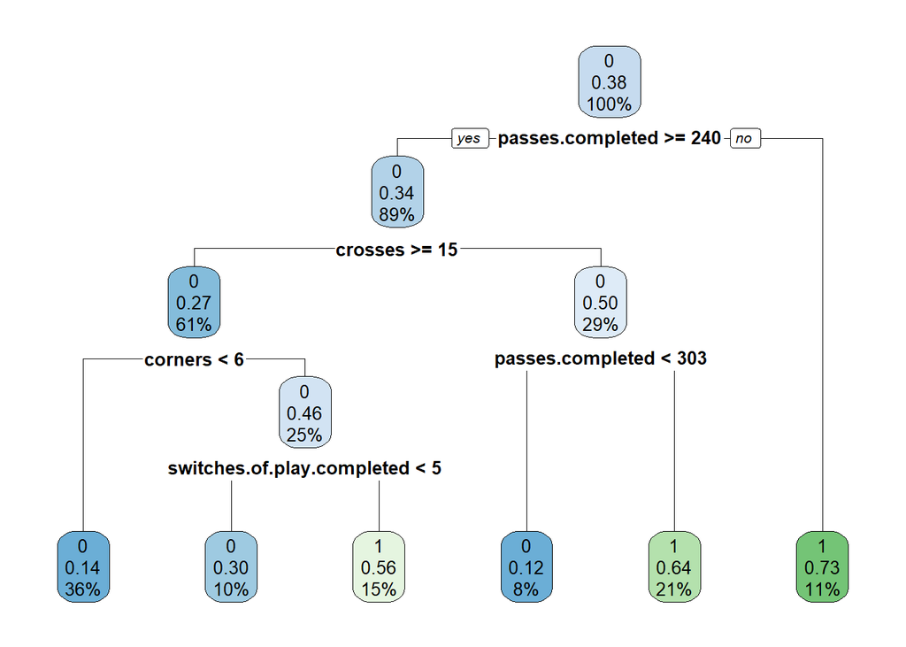

```r
rpart.plot(model_tree2)
```

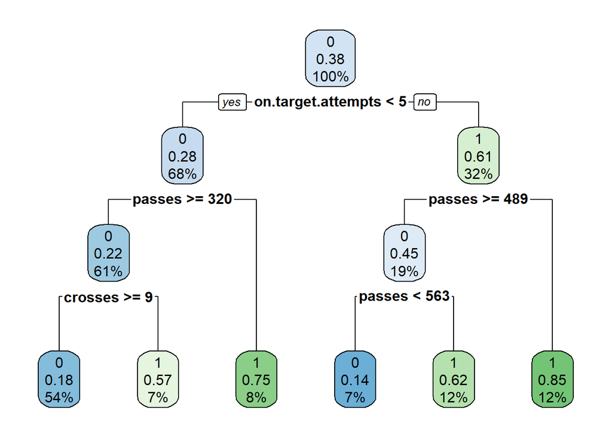

```r
rpart.plot(model_tree3)
```

The `rpart.plot()` function allows you to visually see the interworkings of the CART models. As stated above, there is a condition that lies between the two branches and depending on which way the variable falls will determine the outcome. Interestingly enough, the model predicts that the team will win if their passes are less than 240, as shown by the first split of the tree. You can go through the tree and see the different thresholds of the variables that causes the model to predict one outcome over the other.

#### CART Models on the Testing Set

```r
predicted_class_tree1 <- predict(model_tree1, newdata = team_test, type = "class")

cm_test_tree1 <- confusionMatrix(as.factor(predicted_class_tree1), as.factor(team_test$result), positive="1")

cm_test_tree1
```

```
## Confusion Matrix and Statistics
##
##           Reference
## Prediction  0  1
##          0 14  3
##          1  1  6
##
##                Accuracy : 0.8333
##                  95% CI : (0.6262, 0.9526)
##     No Information Rate : 0.625
##     P-Value [Acc > NIR] : 0.02435
##
##                   Kappa : 0.6279
##
##  Mcnemar's Test P-Value : 0.61708
##
##             Sensitivity : 0.6667
##             Specificity : 0.9333
##          Pos Pred Value : 0.8571
##          Neg Pred Value : 0.8235
##              Prevalence : 0.3750
##          Detection Rate : 0.2500
##    Detection Prevalence : 0.2917
##       Balanced Accuracy : 0.8000
##
##        'Positive' Class : 1
##
```

```r
predicted_class_tree2 <- predict(model_tree2, newdata = team_test, type = "class")

cm_test_tree2 <- confusionMatrix(as.factor(predicted_class_tree2), as.factor(team_test$result), positive="1")

cm_test_tree2
```

```
## Confusion Matrix and Statistics
##
##           Reference
## Prediction 0 1
##          0 7 4
##          1 8 5
##
##                Accuracy : 0.5
##                  95% CI : (0.2912, 0.7088)
##     No Information Rate : 0.625
##     P-Value [Acc > NIR] : 0.9281
##
##                   Kappa : 0.0204
##
##  Mcnemar's Test P-Value : 0.3865
##
##             Sensitivity : 0.5556
##             Specificity : 0.4667
##          Pos Pred Value : 0.3846
##          Neg Pred Value : 0.6364
##              Prevalence : 0.3750
##          Detection Rate : 0.2083
##    Detection Prevalence : 0.5417
##       Balanced Accuracy : 0.5111
##
##        'Positive' Class : 1
##
```

```r
predicted_class_tree3 <- predict(model_tree3, newdata = team_test, type = "class")

cm_test_tree3 <- confusionMatrix(as.factor(predicted_class_tree3), as.factor(team_test$result), positive="1")

cm_test_tree3
```

```
## Confusion Matrix and Statistics
##
##           Reference
## Prediction  0  1
##          0 11  2
##          1  4  7
##
##                Accuracy : 0.75
##                  95% CI : (0.5329, 0.9023)
##     No Information Rate : 0.625
##     P-Value [Acc > NIR] : 0.1453
##
##                   Kappa : 0.4894
##
##  Mcnemar's Test P-Value : 0.6831
##
##             Sensitivity : 0.7778
##             Specificity : 0.7333
##          Pos Pred Value : 0.6364
##          Neg Pred Value : 0.8462
##              Prevalence : 0.3750
##          Detection Rate : 0.2917
##    Detection Prevalence : 0.4583
##       Balanced Accuracy : 0.7556
##
##        'Positive' Class : 1
##
```

```r
# CART Model #1
sprintf("Decision Tree Model #1 - Test Set:  Accuracy = %8.4f  Sensitivity = %8.4f  Specificity = %8.4f  F1 = %8.4f",
        cm_test_tree1$overall["Accuracy"],
        cm_test_tree1$byClass["Sensitivity"],
        cm_test_tree1$byClass["Specificity"],
        cm_test_tree1$byClass["F1"])
```

```
## [1] "Decision Tree Model #1 - Test Set:  Accuracy =   0.8333  Sensitivity =   0.6667  Specificity =   0.9333  F1 =   0.7500"
```

```r
# CART Model #2
sprintf("Decision Tree Model #2 - Test Set:  Accuracy = %8.4f  Sensitivity = %8.4f  Specificity = %8.4f  F1 = %8.4f",
        cm_test_tree2$overall["Accuracy"],
        cm_test_tree2$byClass["Sensitivity"],
        cm_test_tree2$byClass["Specificity"],
        cm_test_tree2$byClass["F1"])
```

```
## [1] "Decision Tree Model #2 - Test Set:  Accuracy =   0.5000  Sensitivity =   0.5556  Specificity =   0.4667  F1 =   0.4545"
```

```r
# CART Model #3
sprintf("Decision Tree Model #3 - Test Set:  Accuracy = %8.4f  Sensitivity = %8.4f  Specificity = %8.4f  F1 = %8.4f",
        cm_test_tree3$overall["Accuracy"],
        cm_test_tree3$byClass["Sensitivity"],
        cm_test_tree3$byClass["Specificity"],
        cm_test_tree3$byClass["F1"])
```

```
## [1] "Decision Tree Model #3 - Test Set:  Accuracy =   0.7500  Sensitivity =   0.7778  Specificity =   0.7333  F1 =   0.7000"
```

## ANSWER: WHAT DOES IT TAKE TO WIN A GAME IN THE 2022 FIFA WORLD CUP?

We can conclude that there is not one single variable that ultimately determines the winner of the match. However, based on or modeling specifically decision tree #3, we found that the variables; `passes`, `on.target.attempts`, `possession`, `receptions.between.midfield.and.defensive.lines`, and `crosses` all play an important roll in determining the result of the match. This was supported by the confusion matrix and its corresponding statistics. They showed the model to be fairly accurate in the prediction of the outcome variable. We can use this as a base assumption, as more time would allow to further dissect this data set. However, our end goal was to address this question but also create a supporting visualizing tool to assist with the EDA through the form of a Shiny App / Dashboard.